# IPD-MA Computer Practical 3

Epidemiology & Big Data

# Preparation

This practical was developed using R version 4.0.3. Open RStudio and verify if your installed version is up-to-date:

```r
R.Version()$version.string
```

If you are unfamiliar with R, an introduction tutorial is available [here](http://r-tutorial.nl/).

# Chapter 1

## Introduction

Deep venous thrombosis (DVT) is a blood clot that forms in a vein in the body (usually in the lower leg or thigh). A (part of such) clot can break off and be carried through the bloodstream to the lungs and cause a blockage (pulmonary embolism), preventing oxygenation of the blood and potentially causing death. Clinical DVT diagnosis is not straightforward. For this reason, multivariable diagnostic prediction models have been developed during the past decades.

In this practical, you will use Individual Participant Data (IPD) sets from 9 studies that recruited consecutive outpatients with suspected deep vein thrombosis (Geersing et al. 2014). These studies were identified by a systematic review and were required to hhave performed D-dimer testing before reference testing; and to document the presence or absence of proximal deep vein thrombosis by an acceptable reference test. Acceptable such tests were either compression ultrasonography or venography at initial presentation, or, if venous imaging was not performed, an uneventful follow-up for at least three months. More information on the included datasets can be found in Geersing et al. (2014).

### 1.1 General aim

During this practical you will practice with developing and validating a model to predict the presence of DVT using IPD originating from 9 studies.

### 1.2 Initialization

Open R and install the packages needed to perform this practical

```r
install.packages(c("MASS", "Hmisc", "rms", "data.table", "glmmLasso", "metafor",
                   "metamisc", "mnormt", "pROC", "car","mvmeta", "glmnet"))
```

Afterwards, we can load the necessary packages:

```r
library(MASS)
library(data.table)
library(mnormt)
library(mvmeta)
```

### 1.3 Exercise data

Download the practicum dataset *dvt_ipd.Rdata* and load the dataset `ipd` by opening the file:

```r
choose.dir(getwd(), "Choose a suitable folder to store output of this practical")
load(file.choose())
```

Let’s first explore the characteristics of the 9 different studies:

| Study | Year | Country | N | Prevalence | Reference | Line of Care |
| --- | --- | --- | --- | --- | --- | --- |
| amuse | 2009 | The Netherlands | 1028 | 13 % | CUS | primary |
| aida | 2003 | The Netherlands | 814 | 39 % | CUS | secondary |
| edit | 2000 | Canada | 153 | 17 % | CUS or venography | secondary |
| kraay | 2002 | The Netherlands | 1756 | 23 % | CUS | secondary |
| toll | 2006 | The Netherlands | 791 | 16 % | CUS | primary |
| edited | 2002 | Canada | 1075 | 18 % | CUS or venography | secondary |
| diem | 2003 | Canada | 541 | 22 % | CUS | secondary |
| stevens | 2004 | United States | 436 | 14 % | CUS | secondary |
| oudega | 2005 | The Netherlands | 1295 | 22 % | CUS | primary |

CUS = compression ultrasonography

**Question 1.** Do you observe any differences between studies conducted in primary and secondary care settings?

```r
head(ipd);dim(ipd)  # show first six rows and dimensions of dataset
n <- unique(length(table(ipd$studyname))) # determine number of studies
data.table(ipd[,-1])[, lapply(.SD, mean), by = studyname] # summarize data per study
data.table(ipd[,-1])[, lapply(.SD, sum), by = studyname]
```

An overview of the variables is given below:  
* **studyid** study identifier  
* **care** care level (primary (=1) / secondary (=0))  
* **country** country of study (Netherlands (=1) / Canada (=2) / Sweden (=3) / United States of America (=4))  
* **sex** sex of participants (male (=1) / female (=0))  
* **age** age (years)  
* **side** Side of legpain (left side (=0) / right side (=1) / both sides (=2))  
* **durat** duration of symptoms  
* **malign** active malignancy  
* **par** paresis  
* **surg** recent surgery (or bedridden)  
* **tend** tenderness venous system  
* **leg** entire leg swollen  
* **calfdif** calf difference  
* **calfdif3** calf difference >= 3 cm  
* **pit** pitting edema  
* **vein** vein distension  
* **altdiagn** alternative diagnosis present  
* **oachst** oral contraceptives or hst  
* **notraum** absence of leg trauma  
* **eryt** erythema  
* **histdvt** history of previous DVT  
* **histpe** history of previous PE  
* **coag** family history of thrombofilia  
* **trav** prolonged travelling  
* **pregn** pregnancy  
* **ddim** d-dimer value  
* **ddimdich** dichotimized d-dimer value  
* **typdim** type of d-dimer assay used (qualitative assay (SimpliRED or Clearview Simplify D-dimer) (=1) / quantitative assay (Latex or Elisa D-dimer) (=2))  
* **dvt** final diagnosis of DVT  
* **studyname** study names

**Question 2.** Which characteristics would you consider to be relevant for predicting presence of DVT in patients with suspected DVT?

# Chapter 2

## Univariable associations

Determine the univariable predictor effects of the included variables within each study.

**Question 3.** Which predictors appear to be highly informative (i.e. strong associations)? Are there any predictor effects that substantially vary across studies?

# Chapter 3

## Multivariable associations

Define predictors of interest (here: chosen arbitrarily, feel free to chose whichever predictors you prefer, based on clinical reasoning, literature and/or univariable associations) NOTE: the number of predictors may be problematic for some studies

```r
explanatory <- c("age","par","tend","leg","pit","altdiagn","histdvt",
                 "malign","surg","calfdif3","vein","oachst","sex","notraum","ddimdich")
```

Alternatively, you could use statistical selection procedures.

### 3.1 predictor selection using LASSO on the overall dataset (ignoring clustering)

We will first apply LASSO to the overall dataset. The LASSO approach penalizes the likelihood function by introducing a parameter `lambda`. Optimal values for this parameter are then first determined via cross-validation, after which the penalized likelihood is optimized. Here, we will use 10-fold cross-validation to determine `lambda`, which can be specified using the argument `nfolds=10`.

```r
library(glmnet)
# Set random seed
set.seed(123)
# determine penalization
lasso.fit <- cv.glmnet(x = as.matrix(subset(ipd,select=explanatory)),
                       y = as.matrix(subset(ipd,select=c(dvt))),
                       family="binomial", type.measure="mse", alpha=1, nfolds=10)

# print coefficients
coef(lasso.fit, s = "lambda.1se")
```

```
## 16 x 1 sparse Matrix of class "dgCMatrix"
##                         1
## (Intercept) -3.194317e+00
## age         -2.396893e-05
## par          .
## tend         6.137009e-02
## leg          2.808745e-01
## pit          .
## altdiagn    -9.740994e-01
## histdvt      .
## malign       4.281384e-01
## surg         9.433021e-02
## calfdif3     5.129627e-01
## vein         7.098922e-02
## oachst       4.068533e-01
## sex          2.945087e-01
## notraum      2.022761e-01
## ddimdich     2.156104e+00
```

As you can see, the variables `par`, `pit` and `histdvt` are omitted from the model.

## 3.2 predictor selection using LASSO with mixed effects

We may also adopt a variable selection approach for generalized linear mixed models by L1-penalized estimation (Groll and Tutz 2014). This approach is related to LASSO, but tailored to multilevel data. We here assume random effects for the intercept term and the predictors `par`, `tend`, `leg`, `calfdif3`, `notraum` and `ddimdich`, in order to allow investigation of between-study heterogeneity in the corresponding regression coefficients. It may, however, be more appropriate to also assume random effects for the remaining predictors.

```r
library(glmmLasso)

fmla <- as.formula(paste("dvt ~", paste(explanatory, collapse="+")))
ipd$study <- as.factor(ipd$studyname)

# Lets try 2 different penalties here.
# The optimal penalty can be identified through cross-validation
lm1 <- glmmLasso(fmla, rnd = list(study=~1+par+tend+leg+calfdif3+notraum+ddimdich),
                 lambda=10, data = ipd, family=binomial())
lm2 <- glmmLasso(fmla, rnd = list(study=~1+par+tend+leg+calfdif3+notraum+ddimdich),
                 lambda=100, data = ipd, family=binomial())
```

Note that in the current LASSO approach, we have pre-specified values for `lambda` rather than estimating appropriate values via cross-validation. The main reason is that cross-validation has not properly been implemented yet for `glmmLasso()`. Hence, we can manually compare 2 prediction models `lm1` (where `lambda=10`) and `lm2` (where `lambda=100`) where we varied the amount of penalization:

```r
data.frame(lm1=coef(lm1), lm2=coef(lm2))
```

```
##                     lm1         lm2
## (Intercept) -3.50851153 -2.46301253
## age          0.00000000  0.00000000
## par          0.03043846  0.00000000
## tend         0.20498516  0.05180715
## leg          0.36750786  0.15690113
## pit          0.05776234  0.03703273
## altdiagn    -1.15846069 -0.92043936
## histdvt      0.43879917  0.07120298
## malign       0.45993118  0.30550944
## surg         0.30383451  0.05317484
## calfdif3     0.52862289  0.37237966
## vein         0.27380417  0.08807968
## oachst       0.76121068  0.29189642
## sex          0.49429683  0.24051772
## notraum      0.34227752  0.04047651
## ddimdich     2.17068718  1.72813746
```

Note that now the predictors `age` and, for the second model, `par` are omitted.

**Question 4.** What could be potential reasons for predictors to not be included in the model?

From here onwards, we will stick to the predictors from the Oudega model (predictors `malign`, `surg`, `calfdif3`, `vein`, `oachst`, `sex`, `notraum`, `ddimdich`), but feel free to adjust the predictors according to information from the LASSO approach or other strategies. (*NOTE: it will actually be nice if some of you select different predictors to allow comparison of your model with fellow students*)

**Question 5.** Define a new dataset including the outcome, study identifiers, and final predictors

# Chapter 4

## Internal-external cross-validation (IECV)

Now, we repeat the above but now we will develop the model using a so-called internal-external cross-validation (IECV), in which we develop the model on `n-1` studies, and validate the model in the remaining study. The procedure is described in full by Debray et al. (2013).

We first introduce lists/variables to store model performance data in the validation populations. Performance data include the c-statistic (`cstat`), the calibration-in-the-large (`citl`), the calibration slope (`calslope`), as well as information on the total number of observed events (`O`), the total number of expected events (`E`), and the total sample size (`N`).

```r
model.perf.val <- data.frame(validation.study=unique(ipd2$studyname),
                             cstat.lb=NA, cstat=NA, cstat.ub=NA,
                             citl=NA, citl.se=NA,
                             calslope=NA, calslope.se=NA,
                             O=NA, E=NA, N=NA)
```

**Question 6.** Explain what aforementioned performance measures mean. How would you interpret the c-statistic, calibration-in-the-large, and the calibration slope?

Run a IECV procedure. During this procedure we will create a PDF of the calibration plots (all are plotted in one PDF file)

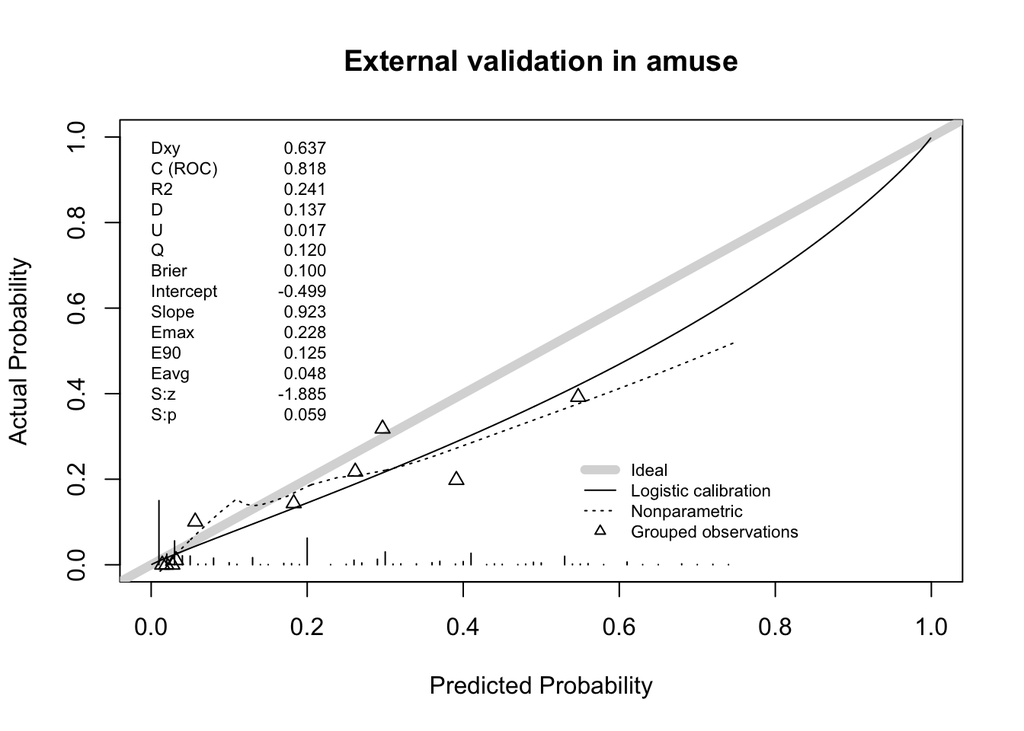

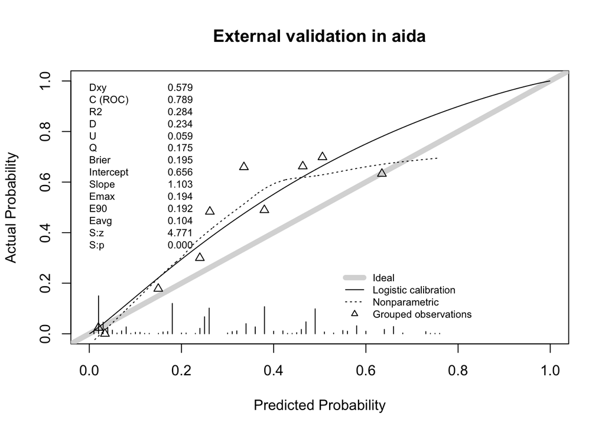

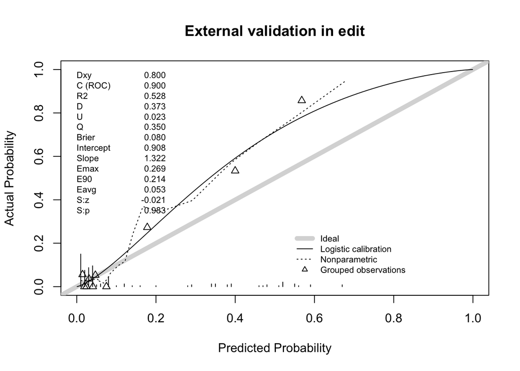

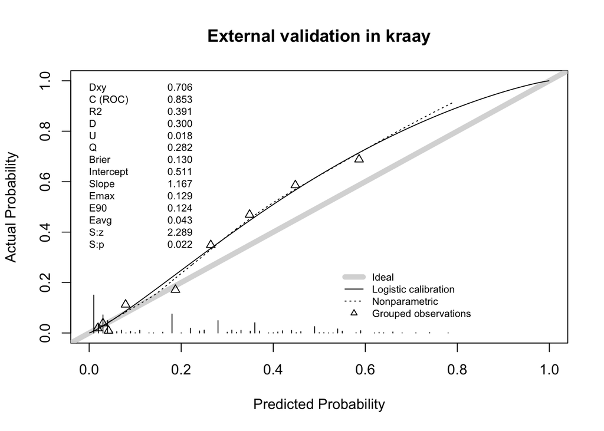

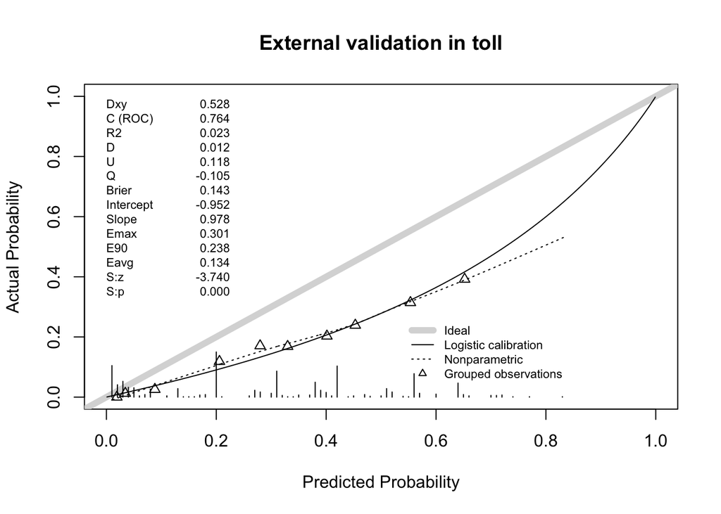

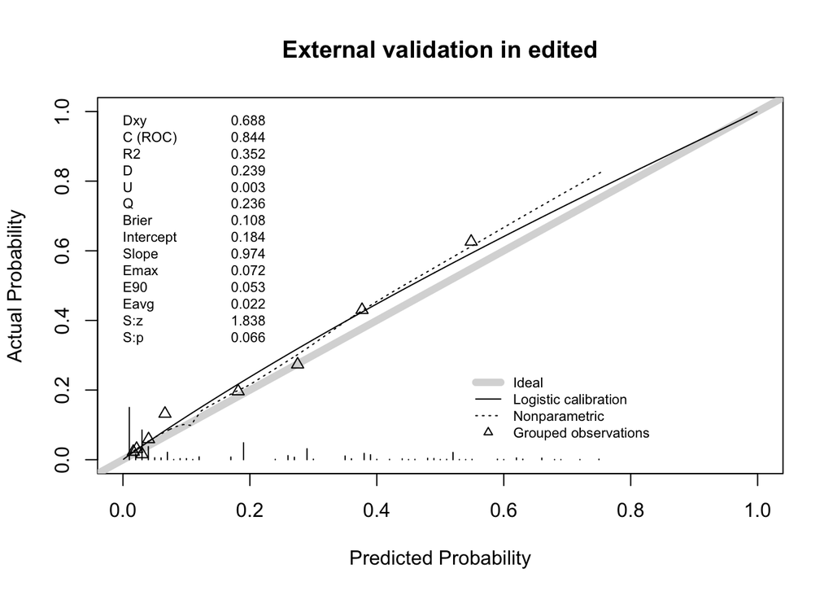

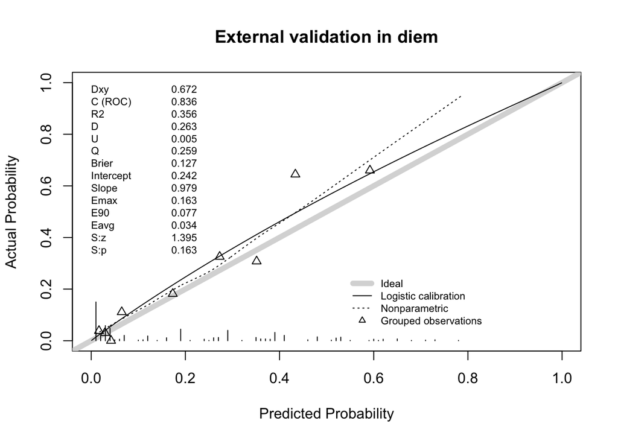

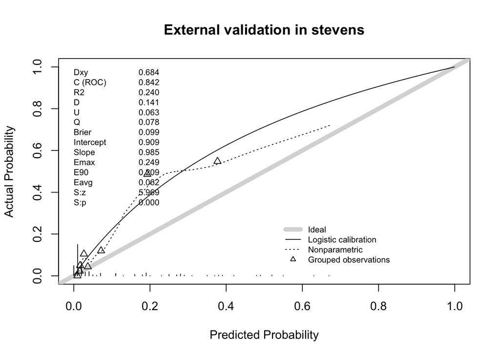

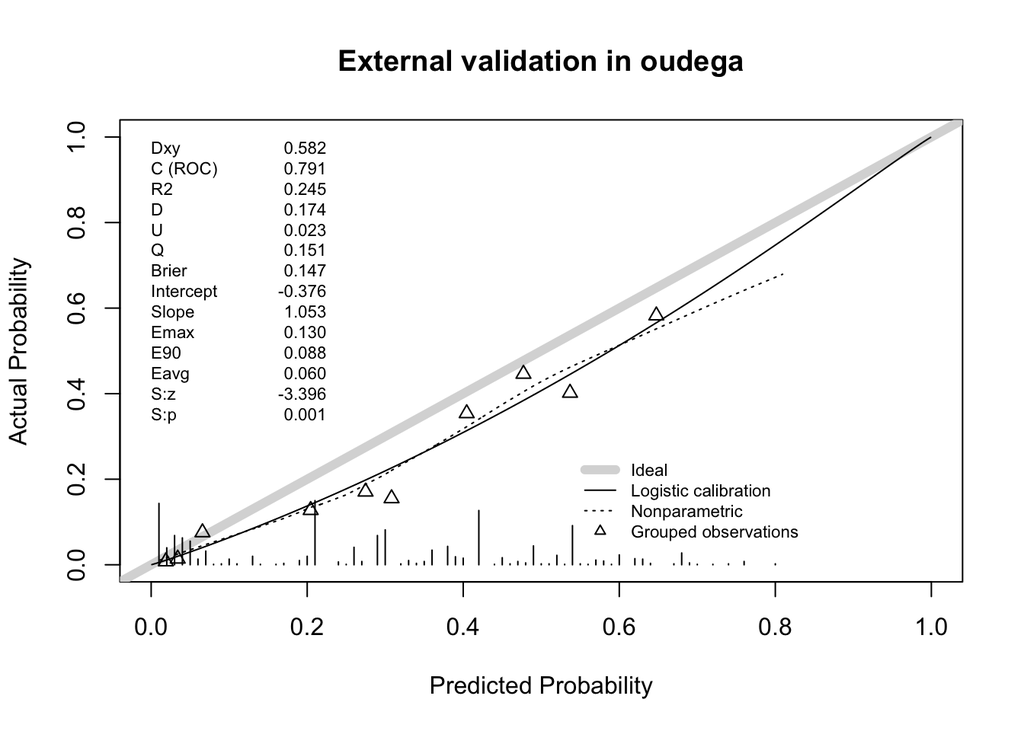

```r
library(pROC)
library(rms)

pdf("calibration_dvt_stacked.pdf")
for(i in 1:nstudies){
  # define development and validation datasets
  ipd.dev <- subset(ipd2,ipd2$studyid!=i,select=-c(studyid,studyname))
  ipd.val <- subset(ipd2,ipd2$studyid==i,select=-c(studyid,studyname))

  # fit model in development data
  fit.dev <- lrm(dvt ~ ., data = ipd.dev)

  predy.val <- predict(fit.dev, type="fitted", newdata=ipd.val)
  predlp.val <- predict(fit.dev, type="lp", newdata=ipd.val)

  # determine calibration slope in validation data
  fit.val.slope <- glm(dvt ~ predlp.val, data=ipd.val, family="binomial")

  # determine calibration-in-the-large in validation data
  fit.val.citl <- glm(dvt ~ 1, offset=predlp.val, data=ipd.val, family="binomial")

  # determine discriminative performance (c statistic) in development and validation sets
  cstat.val <- roc(ipd.val$dvt, predy.val,ci=T)$ci[1:3]

  # determine calibration in development set (plots + intercept / slope)
  val.prob(predy.val, ipd.val$dvt,g=10,
           xlab = paste("Predicted Probabiliy Validation, in study =",paste(i)),
           ylab = paste("Actual Probabiliy Validation, in study =",paste(i)))

  model.perf.val$validation.study[i] <- (ipd$studyname[which(ipd$studyid==i)])[1]
  model.perf.val$cstat.lb[i] <- cstat.val[1]
  model.perf.val$cstat[i] <- cstat.val[2]
  model.perf.val$cstat.ub[i] <- cstat.val[3]
  model.perf.val$citl[i] <- fit.val.citl$coef[1]
  model.perf.val$citl.se[i] <- sqrt(diag(vcov(fit.val.citl)))[1]
  model.perf.val$calslope[i] <- fit.val.slope$coef[2]
  model.perf.val$calslope.se[i] <- sqrt(diag(vcov(fit.val.slope)))[2]
  model.perf.val$O[i] <- sum(ipd.val$dvt)
  model.perf.val$E[i] <-sum(predy.val)
  model.perf.val$N[i] <- dim(ipd.val)[1]
}
dev.off() # this statement terminates the PDF statement
```

**Question 7.** Inspect the calibration plots. Do you observe any peculiarities (e.g. mis-calibration)? Are these peculiarities a common phenomenon or do they only occur in specific data sets?

Recently, internal-external cross-validation has been implemented in the `metapred` function of the R package metamisc. Briefly, this approach will fit a pre-specified model separately in each study of the development sample, and pool the corresponding regression coefficients using random effects meta-analysis. The resulting model is then validated in the hold-out sample. Because the two-stage meta-analysis approach is more prone to estimation problems due to restricted sample size, we will use all variables except for `vein`.

```
## Call: metapred(data = ipd2, strata = "studyname", formula = f, scope = f,
##     family = binomial)
##
## Started with model:
## dvt ~ malign + surg + calfdif3 + oachst + sex + notraum + ddimdich
##
## Generalizability:
##   unchanged
## 1 0.1252423
##
## Cross-validation stopped after 0 steps, as no changes were requested. Final model:
## Meta-analytic model of prediction models estimated in 9 strata. Coefficients:
## (Intercept)      malign        surg    calfdif3      oachst         sex     notraum    ddimdich
##  -4.5081436   0.5213894   0.3786508   1.0666247   0.6300266   0.4965409   0.6010044   2.7726126
```

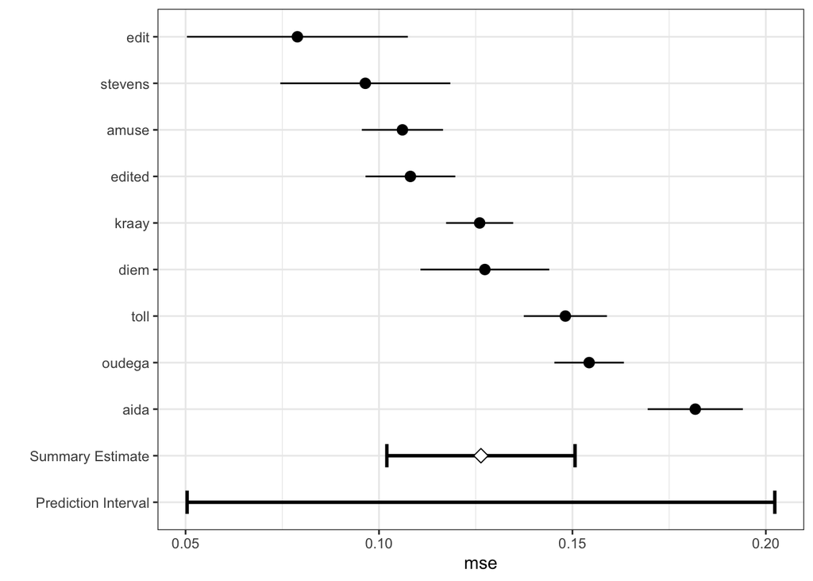

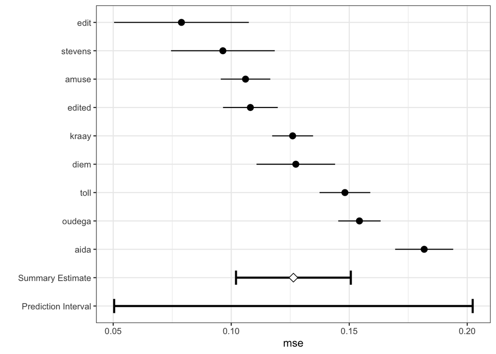

# Chapter 5

## Synthesis of performance results

Evaluate the results of the previous section.

### 5.1 Visual assessment

**Question 8.** Summarize the performance of your model. What is the “average” concordance statistic, calibration slope and calibration-in-the-large statistic upon external validation? How would you interpret these “average” results?

```r
apply(model.perf.val, 2, FUN = median)[c("cstat","citl","calslope")]
```

```
##        cstat         citl     calslope
##  "0.8361078" " 0.5772483"  "0.9845390"
```

We can obtain more appropriate summary estimates by applying random effects meta-analysis. To this purpose, we will use the `metafor` and `metamisc` packages:

```r
library(metafor)
library(metamisc)
```

As you may have noticed, evaluating the various calibration plots is not very straightforward. It may therefore be more helpful to extract the relevant performance statistics and construct so-called forest plots.

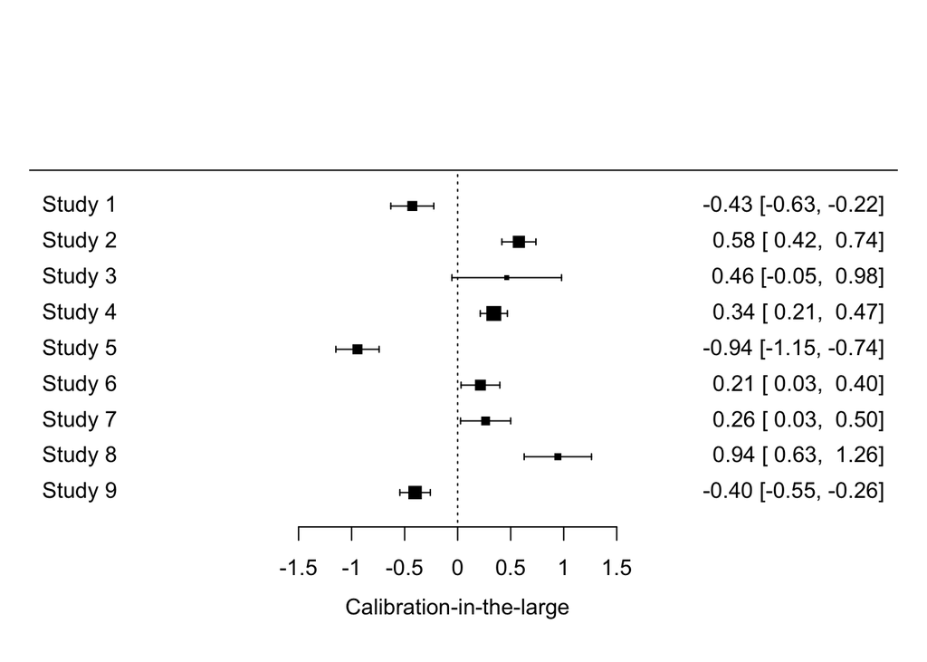

```r
metafor::forest(x = model.perf.val$citl, sei = model.perf.val$citl.se,
                refline = 0, xlab = "Calibration-in-the-large")
```

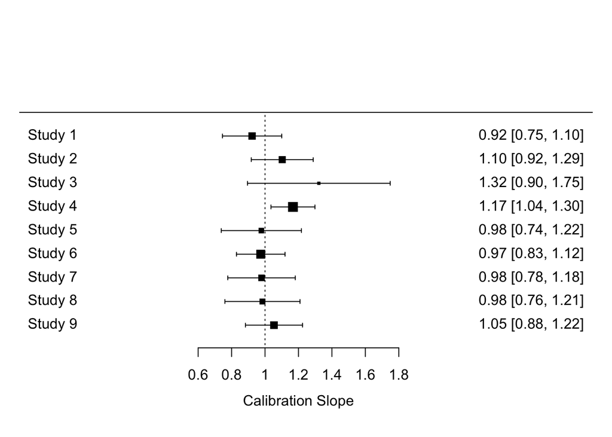

```r
metafor::forest(x = model.perf.val$calslope, sei = model.perf.val$calslope.se,
                refline = 1, xlab = "Calibration Slope")
```

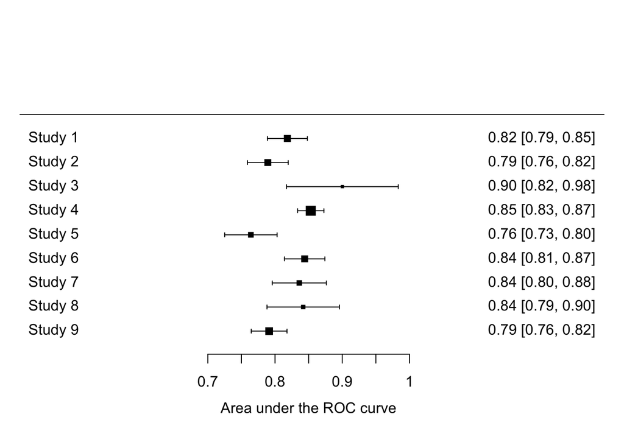

```r
metafor::forest(x = model.perf.val$cstat, ci.lb = model.perf.val$cstat.lb,
                ci.ub = model.perf.val$cstat.ub,
                refline = NA, xlab = "Area under the ROC curve")
```

**Question 9.** Inspect the presence of between-study heterogeneity in model discrimination. Does the C-statsitic substantially vary across studies? What might be potential reasons for this?

**Question 10.** Inspect the presence of heterogeneity in calibration performance. Does the calibration-in-the-large and calibration slope substantially vary across studies? What might be potential reasons for this?

Another way of looking at the calibration performance is to compare the total number of observed (`O`) with total number of predicted (`E`) events in each validation. The total O:E ratio provides a rough indication of the overall model calibration, and is strongly related to the calibration-in-the-large statistic (but may be easier to interpret). We can calculate the total O:E ratio for each validation study as follows. Note that we apply a log transformation to facilitate meta-analysis.

```r
# Calculate the log O:E ratio and its standard error
oe.ad <- oecalc(O=O, E=E, N=N, data=model.perf.val, g="log(OE)")
model.perf.val$logOE <- oe.ad$theta
model.perf.val$logOE.se <- oe.ad$theta.se
```

We can then generate a forest plot for the O:E ratio:

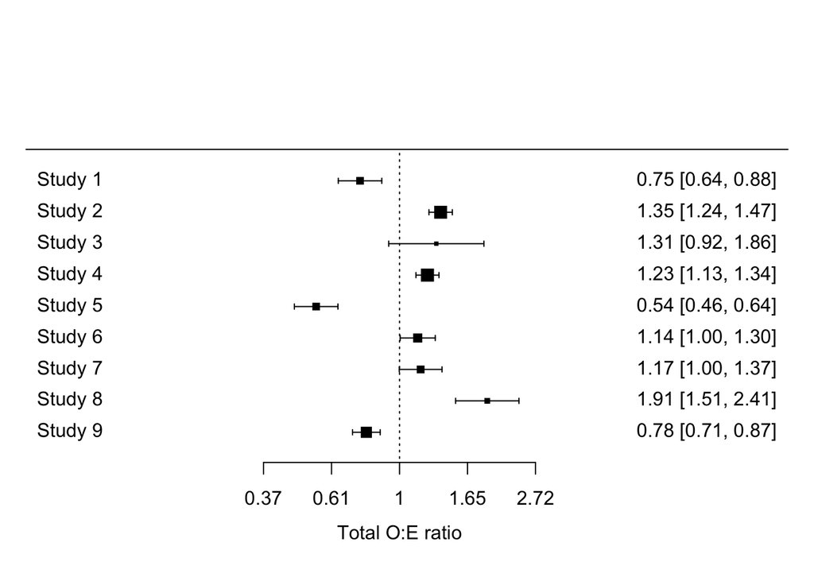

```r
metafor::forest(x = model.perf.val$logOE, sei = model.perf.val$logOE.se,
                atrans = exp, xlab = "Total O:E ratio")
```

## 5.2 Meta-analysis of model performance

Here we will verify your answers to previous questions by performing meta-analysis of prediction model performance. A step-by-step guide on how to do this is presented by Debray et al. (2017).

### 5.2.1 Calibration-in-the-large

Summarize the estimates of the calibration-in-the-large. To account for the potential presence of between-study heterogeneity we recommend a random effects meta-analysis. In line with previous recommendations, we propose to adopt restricted maximum likelihood estimation (`method="REML"`) and to use the Hartung-Knapp-Sidik-Jonkman method (`test = "knha"`) when calculating 95% confidence intervals for the average performance, to better account for the uncertainty in the estimated between-study heterogeneity.

```r
model.CITL <- rma(yi = citl, sei = citl.se, method = "REML",
               test = "knha", data = model.perf.val)
summary(model.CITL)
```

```
##
## Random-Effects Model (k = 9; tau^2 estimator: REML)
##
##   logLik  deviance       AIC       BIC      AICc
##  -7.1502   14.3005   18.3005   18.4593   20.7005
##
## tau^2 (estimated amount of total heterogeneity): 0.3339 (SE = 0.1750)
## tau (square root of estimated tau^2 value):      0.5778
## I^2 (total heterogeneity / total variability):   97.24%
## H^2 (total variability / sampling variability):  36.17
##
## Test for Heterogeneity:
## Q(df = 8) = 251.2261, p-val < .0001
##
## Model Results:
##
## estimate      se    tval    pval    ci.lb   ci.ub
##   0.1048  0.1970  0.5317  0.6094  -0.3495  0.5591
##
## ---
## Signif. codes:  0 '***' 0.001 '**' 0.01 '*' 0.05 '.' 0.1 ' ' 1
```

**Question 11.** What is the pooled estimate for the calibration-in-the-large? Provide the 95% confidence interval.

### 5.2.2 Total O:E ratio

We can also calculate a summary estimate for the total O:E ratio. This ratio indicates whether, on average, our model tends to over-predict (O:E<1) or under-predict (O:E>1) the presence of DVT. Here, we will use the package `metamisc` to adopt the necessary transformations during meta-analysis:

```r
model.OE <- with(model.perf.val, valmeta(measure = "OE", O = O, E = E, N = N))
model.OE
```

```
## Summary Total O:E ratio with 95% confidence and (approximate) 95% prediction interval:
##
##  Estimate       CIl       CIu       PIl       PIu
## 1.0583246 0.7916031 1.4149149 0.4237079 2.6434509
##
## Number of studies included:  9
```

### 5.2.3 Calibration slope

Summarize the estimates of the calibration slope. To account for the heterogeneity that is present we (as is generally recommended) perform a random effects meta-analysis.

```r
model.CS <- rma(yi = calslope, sei = calslope.se,
                method = "REML", test = "knha", data = model.perf.val)
summary(model.CS)
```

```
##
## Random-Effects Model (k = 9; tau^2 estimator: REML)
##
##   logLik  deviance       AIC       BIC      AICc
##   6.5040  -13.0081   -9.0081   -8.8492   -6.6081
##
## tau^2 (estimated amount of total heterogeneity): 0.0021 (SE = 0.0053)
## tau (square root of estimated tau^2 value):      0.0457
## I^2 (total heterogeneity / total variability):   18.82%
## H^2 (total variability / sampling variability):  1.23
##
## Test for Heterogeneity:
## Q(df = 8) = 9.0367, p-val = 0.3392
##
## Model Results:
##
## estimate      se     tval    pval   ci.lb   ci.ub
##   1.0399  0.0332  31.2744  <.0001  0.9632  1.1165  ***
##
## ---
## Signif. codes:  0 '***' 0.001 '**' 0.01 '*' 0.05 '.' 0.1 ' ' 1
```

**Question 12.** What is the pooled estimate for the calibration slope? Provide the 95% confidence interval.

### 5.2.4 Concordance statistic

We can use `metamisc` to perform a random effects meta-analysis of the concordance statistic. This package will apply a logit transformation as recommended by Snell et al. (2018).

```r
model.cstat <- valmeta(cstat = cstat, cstat.cilb = cstat.lb, cstat.ciub = cstat.ub,
                       data = model.perf.val)
model.cstat
```

```
## Summary c-statistic with 95% confidence and (approximate) 95% prediction interval:
##
##  Estimate       CIl       CIu       PIl       PIu
## 0.8186195 0.7910871 0.8432425 0.7362892 0.8794546
##
## Number of studies included:  9
```

### 5.2.5 Overview of performance estiamtes

An overview for all performance estimates, and their 95% prediction interval is given below:

| Performance statistic | Summary | lower CI | upper CI | lower PI | upper PI |
| --- | --- | --- | --- | --- | --- |
| Calibration-in-the-large | 0.1 | -0.35 | 0.56 | -1.3 | 1.51 |
| Total O:E ratio | 1.06 | 0.79 | 1.41 | 0.42 | 2.64 |
| Calibration slope | 1.04 | 0.96 | 1.12 | 0.91 | 1.17 |
| Concordance statistic | 0.82 | 0.79 | 0.84 | 0.74 | 0.88 |

**Question 13.** Determine whether your model would be sufficiently adequate for use in routine care. Would you recommend any tailoring before implementation?

# Chapter 6

## Meta-regression

We will now assess different sources of between-study heterogeneity using meta-regression we specifically focus on whether care setting (primary / secondary), and mean age can explain some of the between-study heterogeneity.

First, add study related characteristics to the `model.perf.val` matrix

```r
# define study level characteristics of interest
model.perf.val$care <- model.perf.val$age.m <- NA

# determine the care, country or mean age per study
for(i in 1:nstudies) {
  model.perf.val$care[i] <- mean(ipd$care[ipd$studyname==model.perf.val$validation.study[i]])
  model.perf.val$age.m[i] <- mean(ipd$age[ipd$studyname==model.perf.val$validation.study[i]])
}
```

Now assess the influence of these characteristics on the model performance measures.

## 6.1 Calibration-in-the-large

We will perform a random effects meta-regression for level of care and mean age.

```r
rma(yi = citl, sei = citl.se, mods = care, method = "REML", test = "knha", data = model.perf.val)
```

```
##
## Mixed-Effects Model (k = 9; tau^2 estimator: REML)
##
## tau^2 (estimated amount of residual heterogeneity):     0.0623 (SE = 0.0408)
## tau (square root of estimated tau^2 value):             0.2495
## I^2 (residual heterogeneity / unaccounted variability): 86.11%
## H^2 (unaccounted variability / sampling variability):   7.20
## R^2 (amount of heterogeneity accounted for):            81.35%
##
## Test for Residual Heterogeneity:
## QE(df = 7) = 41.9618, p-val < .0001
##
## Test of Moderators (coefficient 2):
## F(df1 = 1, df2 = 7) = 29.0781, p-val = 0.0010
##
## Model Results:
##
##          estimate      se     tval    pval    ci.lb    ci.ub
## intrcpt    0.4519  0.1152   3.9220  0.0057   0.1794   0.7244  **
## mods      -1.0380  0.1925  -5.3924  0.0010  -1.4932  -0.5829  **
##
## ---
## Signif. codes:  0 '***' 0.001 '**' 0.01 '*' 0.05 '.' 0.1 ' ' 1
```

```r
rma(yi = citl, sei = citl.se, mods = age.m, method = "REML", test = "knha", data = model.perf.val)
```

```
##
## Mixed-Effects Model (k = 9; tau^2 estimator: REML)
##
## tau^2 (estimated amount of residual heterogeneity):     0.3230 (SE = 0.1796)
## tau (square root of estimated tau^2 value):             0.5684
## I^2 (residual heterogeneity / unaccounted variability): 97.16%
## H^2 (unaccounted variability / sampling variability):   35.17
## R^2 (amount of heterogeneity accounted for):            3.25%
##
## Test for Residual Heterogeneity:
## QE(df = 7) = 243.2923, p-val < .0001
##
## Test of Moderators (coefficient 2):
## F(df1 = 1, df2 = 7) = 1.2423, p-val = 0.3018
##
## Model Results:
##
##          estimate      se     tval    pval    ci.lb    ci.ub
## intrcpt    5.3559  4.7155   1.1358  0.2934  -5.7945  16.5064
## mods      -0.0905  0.0812  -1.1146  0.3018  -0.2823   0.1014
##
## ---
## Signif. codes:  0 '***' 0.001 '**' 0.01 '*' 0.05 '.' 0.1 ' ' 1
```

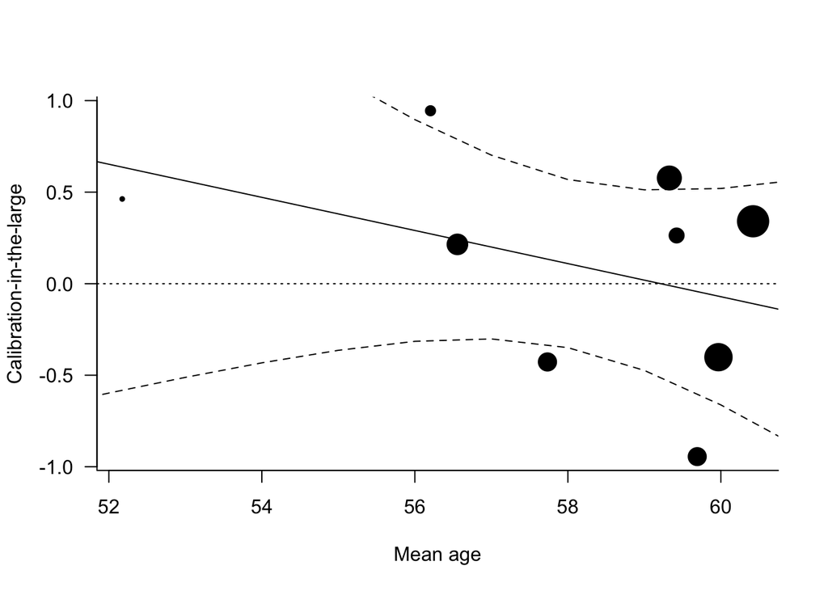

## 6.2 Calibration slope

Perform a random effects meta-regression for the calibration slope.

```r
rma(yi = calslope, sei = calslope.se, mods = care, method = "REML", test = "knha",
    data = model.perf.val)
```

```
##
## Mixed-Effects Model (k = 9; tau^2 estimator: REML)
##
## tau^2 (estimated amount of residual heterogeneity):     0.0019 (SE = 0.0057)
## tau (square root of estimated tau^2 value):             0.0438
## I^2 (residual heterogeneity / unaccounted variability): 17.23%
## H^2 (unaccounted variability / sampling variability):   1.21
## R^2 (amount of heterogeneity accounted for):            8.25%
##
## Test for Residual Heterogeneity:
## QE(df = 7) = 7.6442, p-val = 0.3650
##
## Test of Moderators (coefficient 2):
## F(df1 = 1, df2 = 7) = 1.2436, p-val = 0.3016
##
## Model Results:
##
##          estimate      se     tval    pval    ci.lb   ci.ub
## intrcpt    1.0653  0.0398  26.7552  <.0001   0.9711  1.1594  ***
## mods      -0.0780  0.0700  -1.1152  0.3016  -0.2434  0.0874
##
## ---
## Signif. codes:  0 '***' 0.001 '**' 0.01 '*' 0.05 '.' 0.1 ' ' 1
```

```r
rma(yi = calslope, sei = calslope.se, mods = age.m, method = "REML", test = "knha",
    data = model.perf.val)
```

```
##
## Mixed-Effects Model (k = 9; tau^2 estimator: REML)
##
## tau^2 (estimated amount of residual heterogeneity):     0.0005 (SE = 0.0049)
## tau (square root of estimated tau^2 value):             0.0229
## I^2 (residual heterogeneity / unaccounted variability): 5.39%
## H^2 (unaccounted variability / sampling variability):   1.06
## R^2 (amount of heterogeneity accounted for):            75.02%
##
## Test for Residual Heterogeneity:
## QE(df = 7) = 8.0147, p-val = 0.3313
##
## Test of Moderators (coefficient 2):
## F(df1 = 1, df2 = 7) = 0.7377, p-val = 0.4188
##
## Model Results:
##
##          estimate      se    tval    pval    ci.lb   ci.ub
## intrcpt    0.1060  1.0898  0.0973  0.9252  -2.4710  2.6831
## mods       0.0160  0.0186  0.8589  0.4188  -0.0280  0.0599
##
## ---
## Signif. codes:  0 '***' 0.001 '**' 0.01 '*' 0.05 '.' 0.1 ' ' 1
```

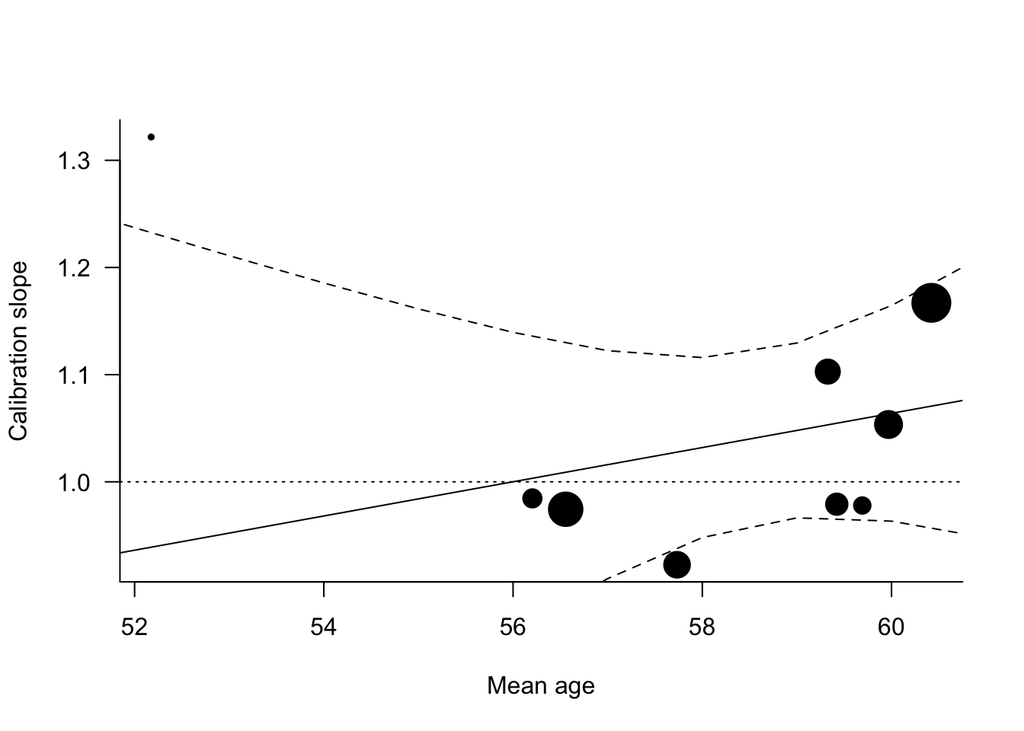

**Question 14.** Which characteristics seem to affect which performance measures?

**Question 15.** Following the previous question. For which populations would tailoring be necessary and how extensive should tailoring be? (intercept only, or also slope? Or even more adjustments needed?)

**Question 16.** If deemed necessary (and if time allows), use the findings from previous questions to refine your model (e.g. by adding or omitting predictors, or by considering more complex associations) and repeat the IECV approach. Do you obtain more favorable results?

# Chapter 7

## Accounting for level of care

In the previous chapter, we identified level of care (`care`) as a major source of between-study heterogeity for the calibration-in-the-large of our model. Hence, we will include this predictor in our revised model.

```r
ipd3 <- ipd[,c("dvt","studyid","studyname","care",xs.final)]
model.perf.val2 <- as.data.frame(array(NA, dim=c(nstudies, 8)))
colnames(model.perf.val2) <- c("validation.study", "cstat.lb", "cstat", "cstat.ub",
                               "citl", "citl.se", "calslope", "calslope.se")

for(i in 1:nstudies){
  # define development and validation datasets
  ipd.dev <- subset(ipd3,ipd$studyid!=i,select=-c(studyid,studyname))
  ipd.val <- subset(ipd3,ipd$studyid==i,select=-c(studyid,studyname))

  # fit model in development data
  fit.dev <- lrm(dvt ~ ., data = ipd.dev)

  # determine calibration slope in validation data
  fit.val.slope <- glm(dvt ~ predict(fit.dev,type="lp",newdata=ipd.val),
                       data = ipd.val, family = "binomial")
  # determine calibration-in-the-large in validation data
  fit.val.citl <- glm(dvt ~ 1, offset=predict(fit.dev,type="lp",newdata=ipd.val),
                      data = ipd.val, family = "binomial")

  # determine discriminative performance (c statistic) in development and validation sets
  cstat.dev <- roc(ipd.dev$dvt,predict(fit.dev,type="fitted"),ci=T)$ci[1:3]
  cstat.val <- roc(ipd.val$dvt,predict(fit.dev,type="fitted",newdata=ipd.val),ci=T)$ci[1:3]


  model.perf.val2[i,] <- c(i, cstat.val,
                          fit.val.citl$coef[1], sqrt(diag(vcov(fit.val.citl)))[1],
                          fit.val.slope$coef[2], sqrt(diag(vcov(fit.val.slope)))[2])
}
```

# Chapter 8

## Comparison of models

Now that we have come up with a certain model specification (through variable selection) and investigated the validity of the corresponding model (via IECV), we can summarize its generalizability for comparison purposes. Hereto, we will determine the probability that our model will achieve a c-statistic of at least 0.7, a calibration-in-the-large between -0.5 and 0.5, and a calibration slope between 0.8 and 1.2 in new populations.

```r
logit <- function(x) { log(x/(1-x))}

calcProbGoodPerf <- function(model.perf.val,
                             min.cstat = 0.7,
                             limits.citl = c(-0.5, 0.5),
                             limits.slope = c(0.8, 1.2))
{
    model.perf.val$logitcstat <- logit(model.perf.val$cstat)
    difflogitc <- logit(model.perf.val$cstat.ub)-logit(model.perf.val$cstat.lb)
    model.perf.val$logitcstat.se <- abs(difflogitc)/(2*qnorm(0.975))

    wsvar <- model.perf.val[,c("citl.se", "calslope.se", "logitcstat.se")]**2

    # Multivariate meta-analysis of calibration-in-the-large, calibration slope and c-statistic
    # Ideally we should provide within-study covariance to argument S, but for sake of simplicity
    # we here assume that, within studies, all performance estimates are independent of each other.
    fit <- mvmeta(cbind(citl, calslope, logitcstat)~1, S=wsvar, data=model.perf.val,
                  method="reml")

    # Simulate 100000 new studies
    Nsim = 1000000
    mvmeta.var <- vcov(fit) # Error (co)variance of the meta-analysis summary estimates

    # Define between-study heterogeneity matrix
    mvmeta.tausq <- fit$Psi

    # Define degrees of freedom
    # Total DF is (#studies - 3) because we have a trivariate MA
    df <- (fit$dim)[["m"]]-3

    # pooled estimates of citl, calibration slope and logit c-statistic
    M = coefficients(fit)

    # Total variance
    V = mvmeta.var + mvmeta.tausq

    # Simulate "true" performance estimates for new studies
    xrand = rmt(Nsim, mean=M, S=V, df=df )

    # Probability of "good" performance
    # cstat > 0.7, citl between -0.5 to 0.5, slope between 0.8 and 1.2
    length(which(xrand[,3]>logit(min.cstat) &
                   xrand[,2] > limits.slope[1] &
                   xrand[,2] < limits.slope[2] &
                   xrand[,1] > limits.citl[1] &
                   xrand[,1] < limits.citl[2]))/Nsim
}

calcProbGoodPerf(model.perf.val)
```

```
## [1] 0.544925
```

```r
calcProbGoodPerf(model.perf.val2)
```

```
## [1] 0.809115
```

# Chapter 9

## Develop final model to be reported

Here we take the Oudega model with level of care as extra predictor because this model yielded the best chance of “good” external performance

```r
ipd.dev <- subset(ipd3, select=-c(studyid,studyname))
fit.final <- glm(dvt~., data = ipd.dev, family=binomial)
summary(fit.final)
```

```
##
## Call:
## glm(formula = dvt ~ ., family = binomial, data = ipd.dev)
##
## Deviance Residuals:
##     Min       1Q   Median       3Q      Max
## -1.8589  -0.6631  -0.2642  -0.1416   3.0356
##
## Coefficients:
##             Estimate Std. Error z value Pr(>|z|)
## (Intercept) -4.30462    0.13093 -32.878  < 2e-16 ***
## care        -0.84629    0.06832 -12.387  < 2e-16 ***
## malign       0.48691    0.09910   4.913 8.96e-07 ***
## surg         0.35657    0.08835   4.036 5.44e-05 ***
## calfdif3     1.07289    0.06544  16.394  < 2e-16 ***
## vein         0.41315    0.08562   4.826 1.40e-06 ***
## oachst       0.74448    0.11566   6.437 1.22e-10 ***
## sex          0.49838    0.06643   7.503 6.24e-14 ***
## notraum      0.55341    0.08808   6.283 3.32e-10 ***
## ddimdich     2.69633    0.10089  26.727  < 2e-16 ***
## ---
## Signif. codes:  0 '***' 0.001 '**' 0.01 '*' 0.05 '.' 0.1 ' ' 1
##
## (Dispersion parameter for binomial family taken to be 1)
##
##     Null deviance: 8152.2  on 7888  degrees of freedom
## Residual deviance: 6028.1  on 7879  degrees of freedom
## AIC: 6048.1
##
## Number of Fisher Scoring iterations: 6
```

# References

Debray, Thomas PA, Johanna AAG Damen, Kym IE Snell, Joie Ensor, Lotty Hooft, Johannes B Reitsma, Richard D Riley, and Karel GM Moons. 2017. “A Guide to Systematic Review and Meta-Analysis of Prediction Model Performance.” *Bmj* 356: i6460.

Debray, Thomas PA, Karel GM Moons, Ikhlaaq Ahmed, Hendrik Koffijberg, and Richard David Riley. 2013. “A Framework for Developing, Implementing, and Evaluating Clinical Prediction Models in an Individual Participant Data Meta-Analysis.” *Statistics in Medicine* 32 (18): 3158–80.

Geersing, GJ, NPA Zuithoff, C Kearon, DR Anderson, AJ Ten Cate-Hoek, JL Elf, SM Bates, et al. 2014. “Exclusion of Deep Vein Thrombosis Using the Wells Rule in Clinically Important Subgroups: Individual Patient Data Meta-Analysis.” *Bmj* 348.

Groll, Andreas, and Gerhard Tutz. 2014. “Variable Selection for Generalized Linear Mixed Models by L 1-Penalized Estimation.” *Statistics and Computing* 24 (2): 137–54.

Snell, Kym IE, Joie Ensor, Thomas PA Debray, Karel GM Moons, and Richard D Riley. 2018. “Meta-Analysis of Prediction Model Performance Across Multiple Studies: Which Scale Helps Ensure Between-Study Normality for the c-Statistic and Calibration Measures?” *Statistical Methods in Medical Research* 27 (11): 3505–22.